# Longitudinal data

Read libraries

```r
library(MASS)
library(tidyverse)
```

```r
library(ggplot2)
library(corrplot)
library(knitr)
library(GGally)
library(sjPlot)
library(effects)
library(carData)
library(FactoMineR)
library(lme4)
```

In this exercise, we use BPRSL and RATS data sets, which are in long form.

BPRS describes Brief psychiatric rating scale that is measured before treatment and the following 8 weeks. There are in total 40 participants and two treatment groups (20 participants in each group). All the participants are males.The data frame has in total 360 observations and 5 variables.

RATS data describes results from a nutrition study. The data contains three groups of rats who have different diets.  
There are in total 176 rows obsercations and 5 variables.

```r
# Read the data sets

BPRS <- read.table("C:/LocalData/kpuukko/IODS-project/data/BPRSL.txt", sep="\t")
RATS <- read.table("C:/LocalData/kpuukko/IODS-project/data/RATSL.txt", sep="\t")

#Explore the structure of the data and check summaries

dim(BPRS)
```

```
## [1] 360   5
```

```r
dim(RATS)
```

```
## [1] 176   5
```

```r
summary(BPRS)
```

```
##    treatment      subject         weeks                bprs            week
##  Min.   :1.0   Min.   : 1.00   Length:360         Min.   :18.00   Min.   :0
##  1st Qu.:1.0   1st Qu.: 5.75   Class :character   1st Qu.:27.00   1st Qu.:2
##  Median :1.5   Median :10.50   Mode  :character   Median :35.00   Median :4
##  Mean   :1.5   Mean   :10.50                      Mean   :37.66   Mean   :4
##  3rd Qu.:2.0   3rd Qu.:15.25                      3rd Qu.:43.00   3rd Qu.:6
##  Max.   :2.0   Max.   :20.00                      Max.   :95.00   Max.   :8
```

```r
summary(RATS)
```

```
##        ID            Group           WD                Weight
##  Min.   : 1.00   Min.   :1.00   Length:176         Min.   :225.0
##  1st Qu.: 4.75   1st Qu.:1.00   Class :character   1st Qu.:267.0
##  Median : 8.50   Median :1.50   Mode  :character   Median :344.5
##  Mean   : 8.50   Mean   :1.75                      Mean   :384.5
##  3rd Qu.:12.25   3rd Qu.:2.25                      3rd Qu.:511.2
##  Max.   :16.00   Max.   :3.00                      Max.   :628.0
##       Time
##  Min.   : 1.00
##  1st Qu.:15.00
##  Median :36.00
##  Mean   :33.55
##  3rd Qu.:50.00
##  Max.   :64.00
```

Next, I will convert categorical variables into factors.

```r
BPRS$treatment <- factor(BPRS$treatment)
BPRS$subject <- factor(BPRS$subject)

RATS$ID <- factor(RATS$ID)
RATS$Group <- factor(RATS$Group)
```

First, let’s plot the RATS data. From the plots below, can see that the weight of the individual rats differ clearly between group 1 and groups 2 and 3. The rats in group 1 have lower starting weights and overall more steady weights compared to other groups. Whereas both in groups 2 and 3 rats weight increase. Also it appears that the weight of rats is higher in group 3 than in group 2.

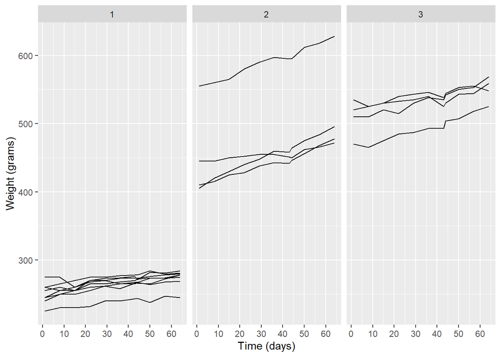

```r
ggplot(RATS, aes(x = Time, y = Weight, group = ID)) +
  geom_line()+
  scale_x_continuous(name = "Time (days)", breaks = seq(0, 60, 10)) +
  scale_y_continuous(name = "Weight (grams)") +
  theme(legend.position = "top") +
  facet_wrap(. ~ Group)
```

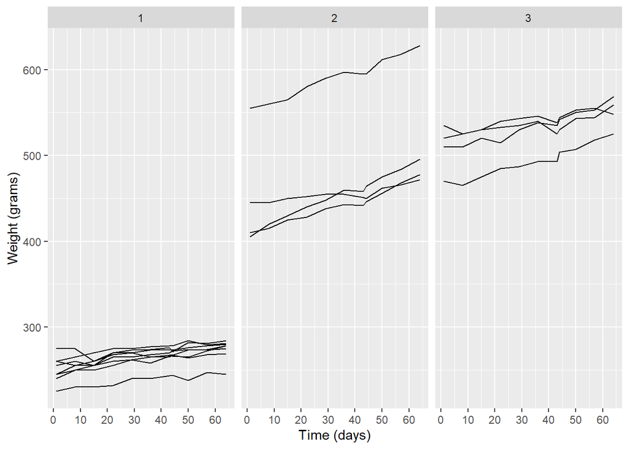

```r
RATS <- RATS %>%
  group_by(Time) %>%
  mutate(stdval = (Weight - mean(Weight))/sd(Weight) ) %>%
  ungroup()

ggplot(RATS, aes(x = Time, y = Weight, group = ID)) +
  geom_line()+
  scale_x_continuous(name = "Time (days)", breaks = seq(0, 60, 10)) +
  scale_y_continuous(name = "Weight (grams)") +
  theme(legend.position = "top") +
  facet_wrap(. ~ Group)
```

Next, I will summarise the measures, the mean and its standard error of the individuals at each time step. The plot below described the group means and the corresponding standard errors (as error bars). The mean weights show again show the same trend: rats in group 3 are the heaviest and in group 1 lightest. Standard errors are largest in group 2, whereas in group 1 very small.

```r
# Summary data with mean and standard error of weight by group and time
n <- RATS$Time %>% unique() %>% length()
n #11
```

```
## [1] 11
```

```r
RATSS <- RATS %>%
  group_by(Group, Time) %>%
  summarise( mean = mean(Weight), se = sd(Weight)/sqrt(n) )%>%
  ungroup()
```

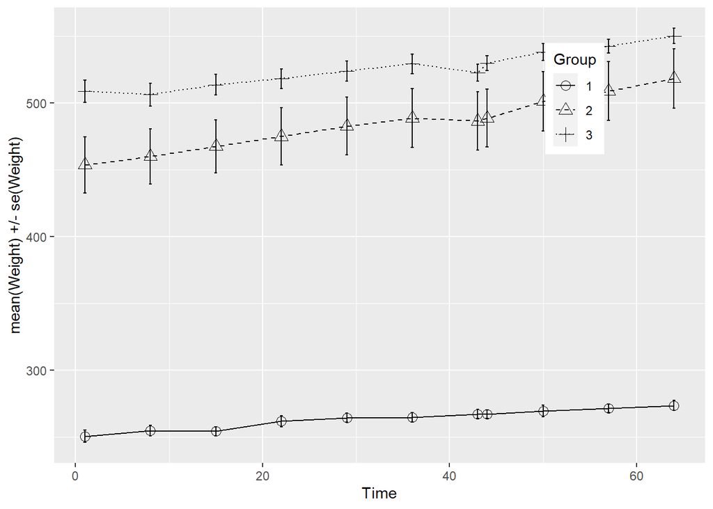

```r
ggplot(RATSS, aes(x = Time, y = mean, linetype = Group, shape = Group)) +
  geom_line() +
  scale_linetype_manual(values = c(1,2,3)) +
  geom_point(size=3) +
  scale_shape_manual(values = c(1,2,3)) +
  geom_errorbar(aes(ymin = mean - se, ymax = mean + se, linetype="1"), width=0.3) +
  theme(legend.position = c(0.8,0.8)) +
  scale_y_continuous(name = "mean(Weight) +/- se(Weight)")
```

Next, I will create a summary data by groups and ID with mean as the summary variable. Below are the box plots of the group means. Again the standard errors appear to be largest in group 2, whereas in group 1 very small. Note there is one clear outlier, which could be removed.

```r
RATSID <- RATS %>%
  group_by(Group, ID) %>%
  summarise( mean=mean(Weight) ) %>%
  ungroup()
```

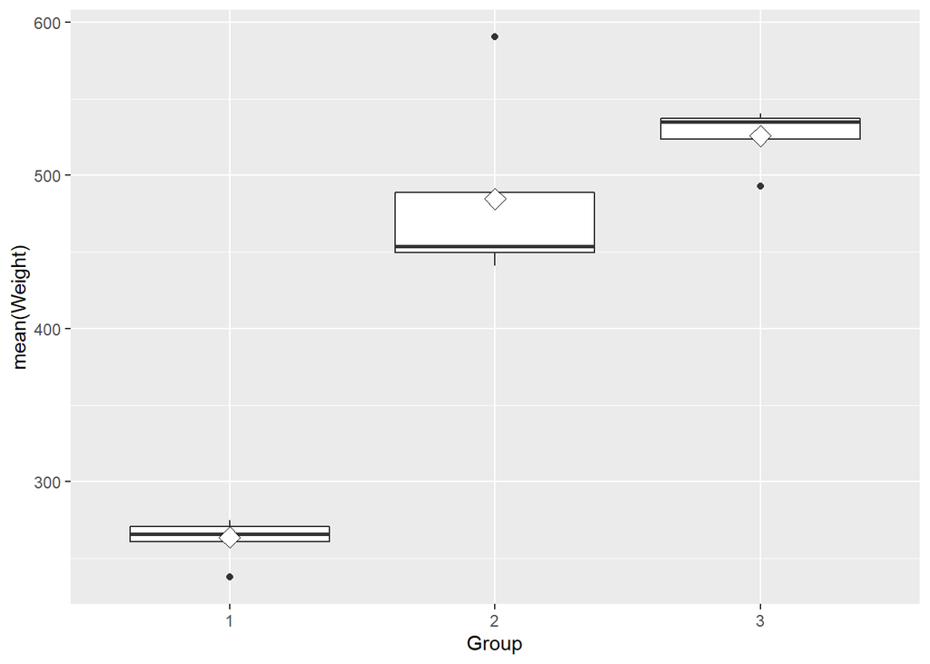

```r
ggplot(RATSID, aes(x = Group, y = mean)) +
  geom_boxplot() +
  stat_summary(fun.y = "mean", geom = "point", shape=23, size=4, fill = "white") +
  scale_y_continuous(name = "mean(Weight)")
```

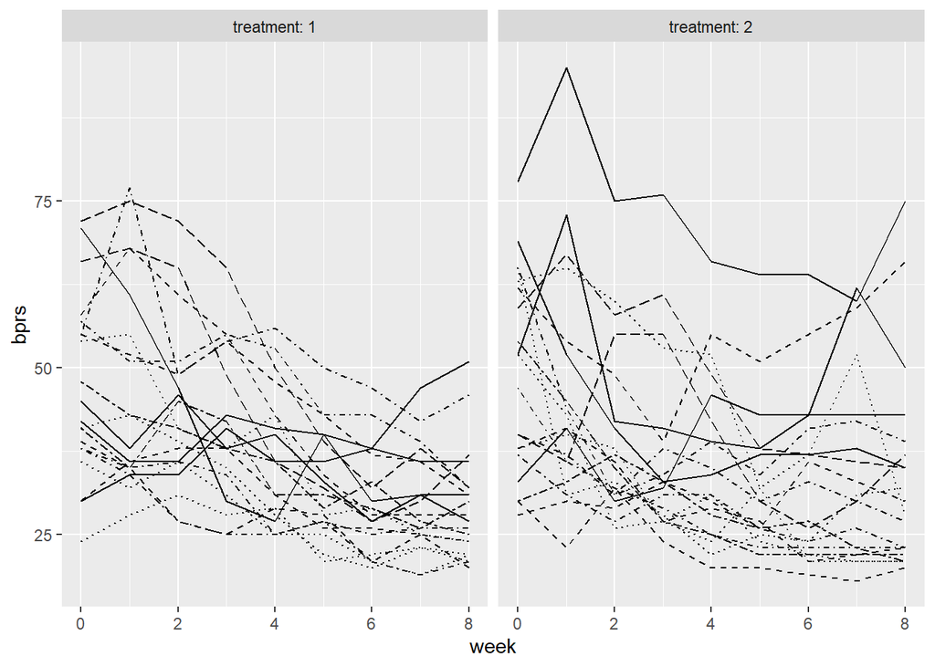

```r
ggplot(BPRS, aes(x = week, y = bprs, linetype = subject)) +
  geom_line() +
  scale_linetype_manual(values = rep(1:10, times=4)) +
  facet_grid(. ~ treatment, labeller = label_both) +
  theme(legend.position = "none") +
  scale_y_continuous(limits = c(min(BPRS$bprs), max(BPRS$bprs)))
```

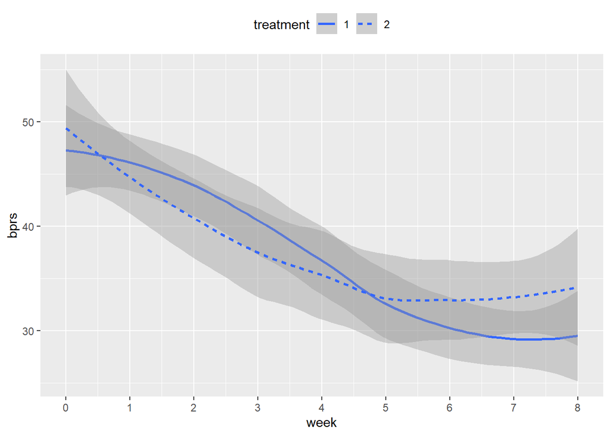

```r
#Basic

ggplot(BPRS, aes(x = week, y = bprs, group = treatment)) +
  geom_smooth(aes(linetype = treatment)) +
  scale_x_continuous(name = "week", breaks = seq(0, 20)) +
  scale_y_continuous(name = "bprs") +
  theme(legend.position = "top")
```

Then, I will conduct a linear regression model with bprs as an outcome and week and treatment as predictors. Week, is significantly related to BPRS, but treatment is not. Multiple R-squared is 0.1851, indicating that so together the model explains less than 20% of the variation in BPRS.

```r
Mod1 <- lm(bprs ~ week + treatment, data = BPRS)
summary(Mod1)
```

```
##
## Call:
## lm(formula = bprs ~ week + treatment, data = BPRS)
##
## Residuals:
##     Min      1Q  Median      3Q     Max
## -22.454  -8.965  -3.196   7.002  50.244
##
## Coefficients:
##             Estimate Std. Error t value Pr(>|t|)
## (Intercept)  46.4539     1.3670  33.982   <2e-16 ***
## week         -2.2704     0.2524  -8.995   <2e-16 ***
## treatment2    0.5722     1.3034   0.439    0.661
## ---
## Signif. codes:  0 '***' 0.001 '**' 0.01 '*' 0.05 '.' 0.1 ' ' 1
##
## Residual standard error: 12.37 on 357 degrees of freedom
## Multiple R-squared:  0.1851, Adjusted R-squared:  0.1806
## F-statistic: 40.55 on 2 and 357 DF,  p-value: < 2.2e-16
```

```r
#Random intercept model
Model2<- lmer(bprs ~ week + treatment + (week | subject), data = BPRS, REML = FALSE)
summary(Model2)
```

```
## Linear mixed model fit by maximum likelihood  ['lmerMod']
## Formula: bprs ~ week + treatment + (week | subject)
##    Data: BPRS
##
##      AIC      BIC   logLik deviance df.resid
##   2745.4   2772.6  -1365.7   2731.4      353
##
## Scaled residuals:
##     Min      1Q  Median      3Q     Max
## -2.8919 -0.6194 -0.0691  0.5531  3.7976
##
## Random effects:
##  Groups   Name        Variance Std.Dev. Corr
##  subject  (Intercept) 64.8222  8.0512
##           week         0.9609  0.9802   -0.51
##  Residual             97.4305  9.8707
## Number of obs: 360, groups:  subject, 20
##
## Fixed effects:
##             Estimate Std. Error t value
## (Intercept)  46.4539     2.1052  22.066
## week         -2.2704     0.2977  -7.626
## treatment2    0.5722     1.0405   0.550
##
## Correlation of Fixed Effects:
##            (Intr) week
## week       -0.582
## treatment2 -0.247  0.000
```

```r
Model3 <- lmer(bprs ~ week + treatment + (week | subject), data = BPRS, REML = FALSE)
summary(Model3)
```

```
## Linear mixed model fit by maximum likelihood  ['lmerMod']
## Formula: bprs ~ week + treatment + (week | subject)
##    Data: BPRS
##
##      AIC      BIC   logLik deviance df.resid
##   2745.4   2772.6  -1365.7   2731.4      353
##
## Scaled residuals:
##     Min      1Q  Median      3Q     Max
## -2.8919 -0.6194 -0.0691  0.5531  3.7976
##
## Random effects:
##  Groups   Name        Variance Std.Dev. Corr
##  subject  (Intercept) 64.8222  8.0512
##           week         0.9609  0.9802   -0.51
##  Residual             97.4305  9.8707
## Number of obs: 360, groups:  subject, 20
##
## Fixed effects:
##             Estimate Std. Error t value
## (Intercept)  46.4539     2.1052  22.066
## week         -2.2704     0.2977  -7.626
## treatment2    0.5722     1.0405   0.550
##
## Correlation of Fixed Effects:
##            (Intr) week
## week       -0.582
## treatment2 -0.247  0.000
```

Finally, I will test the model with interaction between treatment and time. The results show that Model4 with interaction is better than Model 3. However, the model improvement is not significant.

```r
Model4 <- lmer(bprs ~ week * treatment + (week | subject), data = BPRS, REML = FALSE)
summary(Model4)
```

```
## Linear mixed model fit by maximum likelihood  ['lmerMod']
## Formula: bprs ~ week * treatment + (week | subject)
##    Data: BPRS
##
##      AIC      BIC   logLik deviance df.resid
##   2744.3   2775.4  -1364.1   2728.3      352
##
## Scaled residuals:
##     Min      1Q  Median      3Q     Max
## -3.0512 -0.6271 -0.0768  0.5288  3.9260
##
## Random effects:
##  Groups   Name        Variance Std.Dev. Corr
##  subject  (Intercept) 64.9964  8.0620
##           week         0.9687  0.9842   -0.51
##  Residual             96.4707  9.8220
## Number of obs: 360, groups:  subject, 20
##
## Fixed effects:
##                 Estimate Std. Error t value
## (Intercept)      47.8856     2.2521  21.262
## week             -2.6283     0.3589  -7.323
## treatment2       -2.2911     1.9090  -1.200
## week:treatment2   0.7158     0.4010   1.785
##
## Correlation of Fixed Effects:
##             (Intr) week   trtmn2
## week        -0.650
## treatment2  -0.424  0.469
## wek:trtmnt2  0.356 -0.559 -0.840
```

```r
anova(Model4, Model3)
```

```
## Data: BPRS
## Models:
## Model3: bprs ~ week + treatment + (week | subject)
## Model4: bprs ~ week * treatment + (week | subject)
##        npar    AIC    BIC  logLik deviance  Chisq Df Pr(>Chisq)
## Model3    7 2745.4 2772.6 -1365.7   2731.4
## Model4    8 2744.3 2775.4 -1364.1   2728.3 3.1712  1    0.07495 .
## ---
## Signif. codes:  0 '***' 0.001 '**' 0.01 '*' 0.05 '.' 0.1 ' ' 1
```

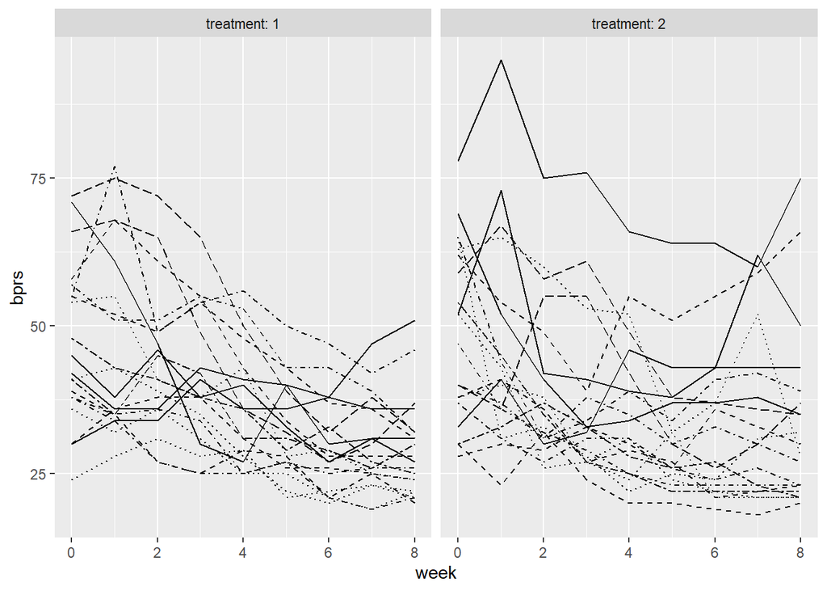

```r
ggplot(BPRS, aes(x = week, y = bprs, linetype = subject)) +
  geom_line() +
  scale_linetype_manual(values = rep(1:10, times=4)) +
  facet_grid(. ~ treatment, labeller = label_both) +
  theme(legend.position = "none") +
  scale_y_continuous(limits = c(min(BPRS$bprs), max(BPRS$bprs)))
```

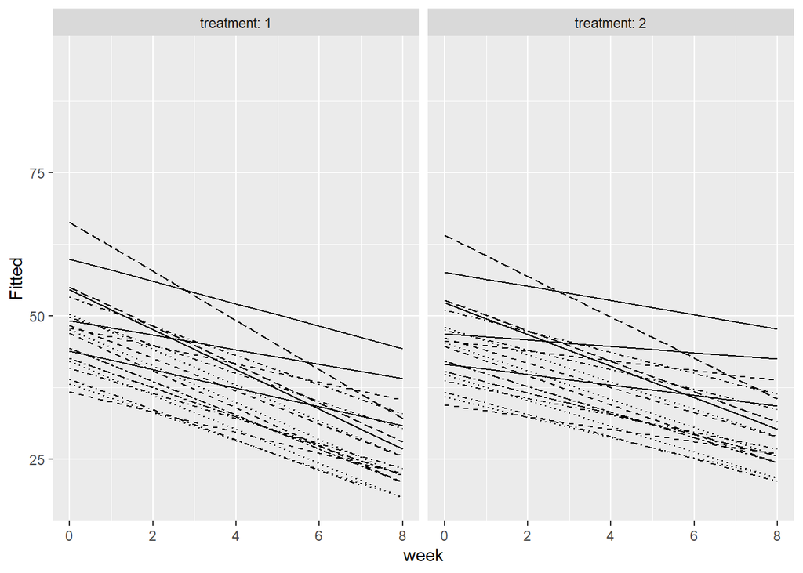

```r
Fitted <- fitted(Model4)

BPRS <- BPRS %>%
  mutate(Fitted)

ggplot(BPRS, aes(x = week, y = Fitted, linetype = subject)) +
  geom_line() +
  scale_linetype_manual(values = rep(1:10, times=4)) +
  facet_grid(. ~ treatment, labeller = label_both) +
  theme(legend.position = "none") +
  scale_y_continuous(limits = c(min(BPRS$bprs), max(BPRS$bprs)))
```